# RelB

Fold-switch pair **1zk9A_3jv6A** — **1zk9A** vs **3jv6A**

Mus musculus

## Figure 1: Phylogenetic tree with per-cluster fold-preference heatmap.

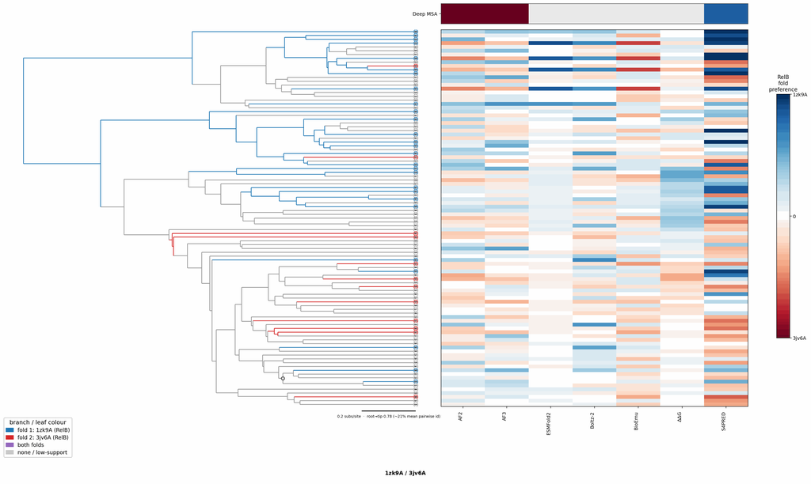

## Figure 2: Aligned overlay (both folds superposed)

The single fold-switching chain of each fold superposed by TM-align; waters hidden, any ligand shown as green sticks. Grey = structurally conserved core, colour = divergent (fold-switching) region.

1zk9A (RelB) · monomer3jv6A (RelB) · dimer

TM-score: 0.534 · Trigger class: protein_binding

Aligned overlay

Loading...

## Figure 3: The two folds, side by side

Each fold is coloured by per-residue Cα deviation between the two superposed structures: grey ≈ conserved core, full colour = structurally divergent (fold-switching) region.

1zk9A (RelB)

3jv6A (RelB)

0 Å5≥10 Å

1zk9A (RelB)

Loading...

3jv6A (RelB)

Loading...

## Figure 4: Best-cluster predicted contact maps over the two true folds.

Predicted contact maps (MSA-Transformer) for the clusters best matching each fold, over the true contacts of fold 1 (upper triangle) and fold 2 (lower). Divergent contacts between clusters are the contact-level signature of fold-switching.

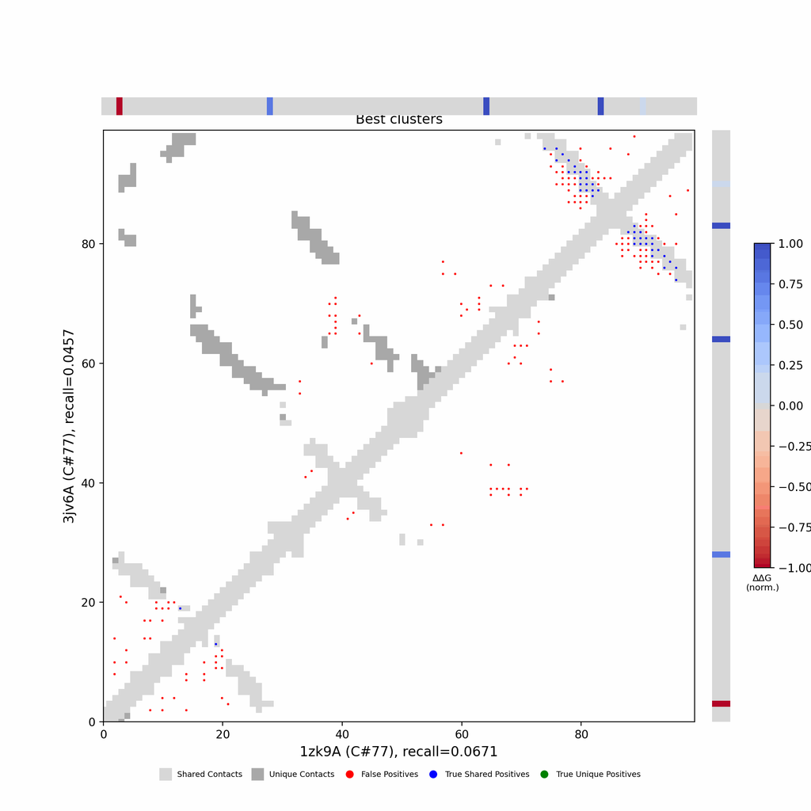

## Figure 5: Per-residue ΔΔG fold-preference contribution

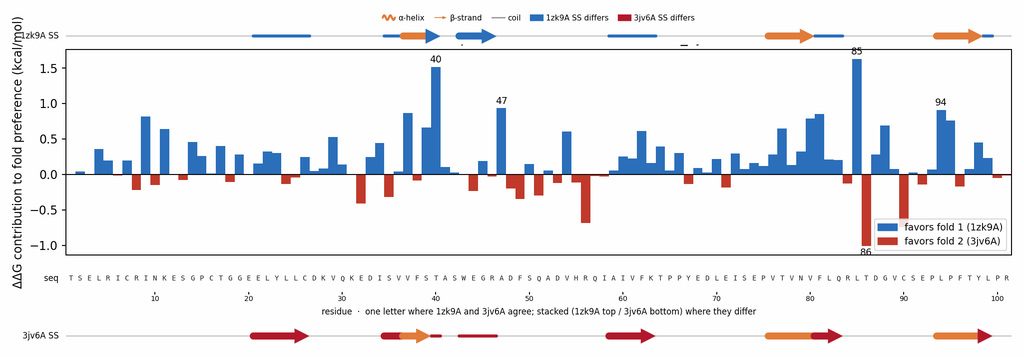

**More figures**

## Figure 6: Deep-MSA contact map panel / Best clusters contact map panel

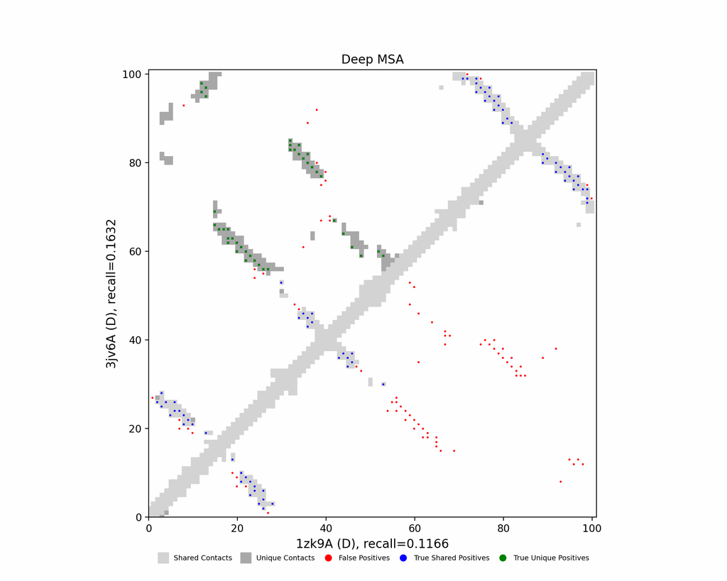

Deep-MSA contact map panel

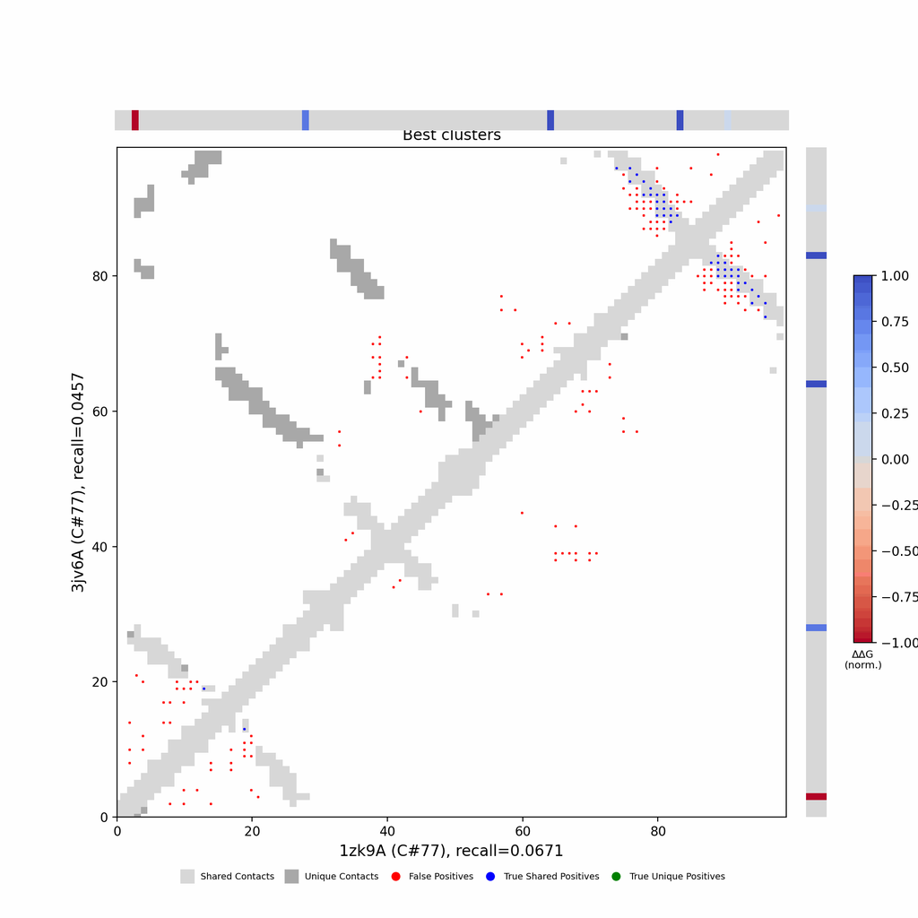

Best clusters contact map panel

## Figure 7: All clusters contact-map mosaic (small multiples).

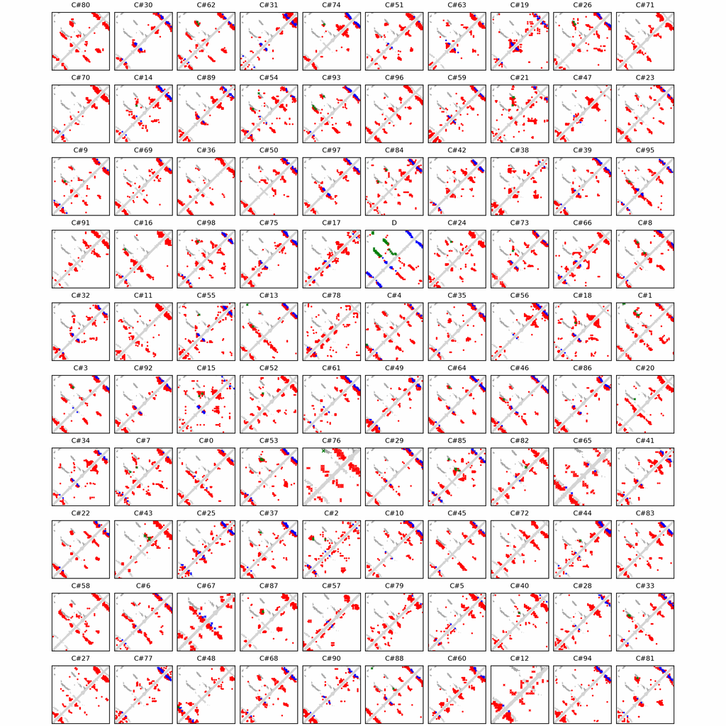

## Figure 8: Phylo null: tree with shuffled cluster fold labels.

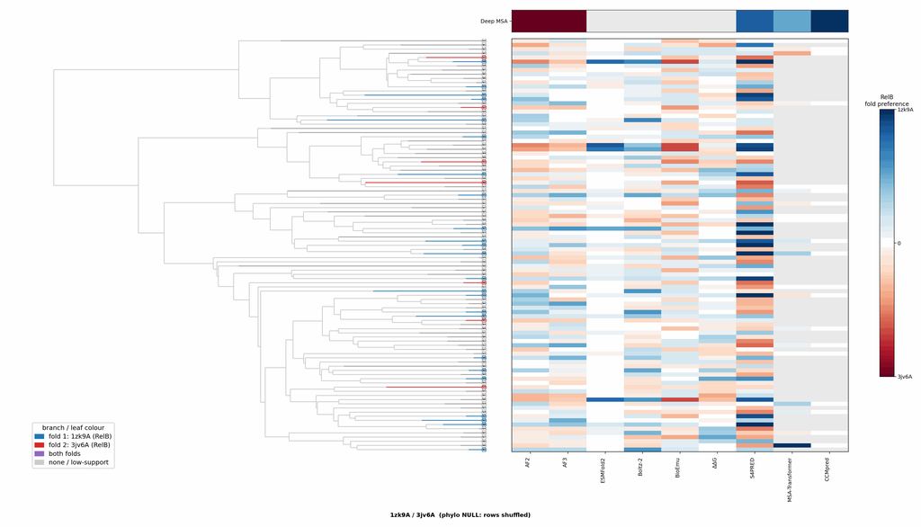

## Cluster metrics table

Per-cluster metrics underlying the figures above.

| cluster | n | neff | AF2_TM1 | AF2_TM2 | AF3_TM1 | AF3_TM2 | RE-MSAT-COM | RE-MSAT1 | RE-MSAT2 | ESM_SEQIDS | ESM_TM1 | ESM_TM2 | ΔΔG_Bias | ΔΔG_Bias_std | ΔΔG_frac_F1 | Boltz2_pref | S4PRED_pref | CCMpred_pref | BioEmu_pref |
| --- | --- | --- | --- | --- | --- | --- | --- | --- | --- | --- | --- | --- | --- | --- | --- | --- | --- | --- | --- |
| Deep | - | - | 0.49 | 0.98 | 0.49 | 0.98 | 0.39 | 0.37 | 0.5 | - | - | - | - | - | - | - | 0.08 | 0.0 | - |
| 000 | 166.0 | 49.0 | 0.21 | 0.29 | 0.25 | 0.36 | 0.0 | 0.03 | 0.0 | 001; 001; 007; 007; 002; 002; 009; 009; 006; 006 | 0.44 ± 0.03 | 0.80 ± 0.15 | 17.29 | 7.28 | 1.0 | -0.32 | -0.04 | 0.0 | -0.05 |
| 001 | 165.0 | 54.0 | 0.32 | 0.59 | 0.43 | 0.82 | 0.0 | 0.01 | 0.02 | 001; 001; 003; 003; 009; 009; 002; 002; 006; 006 | 0.43 ± 0.04 | 0.85 ± 0.07 | 15.11 | 8.73 | 0.9 | -0.28 | 0.02 | 0.0 | -0.23 |
| 002 | 146.0 | 3.0 | 0.29 | 0.54 | 0.46 | 0.87 | 0.0 | 0.0 | 0.0 | 001; 001; 003; 003; 008; 008; 002; 002; 004; 004 | 0.46 ± 0.02 | 0.90 ± 0.04 | 24.26 | 5.07 | 1.0 | -0.11 | -0.04 | 0.0 | -0.13 |
| 003 | 144.0 | 54.0 | 0.33 | 0.62 | 0.33 | 0.63 | 0.02 | 0.02 | 0.01 | 001; 001; 003; 002; 003; 002; 004; 004; 010; 010 | 0.45 ± 0.03 | 0.73 ± 0.26 | 18.32 | 7.26 | 1.0 | -0.38 | -0.01 | 0.0 | -0.08 |
| 004 | 133.0 | 38.0 | 0.34 | 0.68 | 0.39 | 0.75 | 0.06 | 0.05 | 0.03 | 004; 004; 001; 003; 001; 003; 006; 009; 010; 006 | 0.47 ± 0.03 | 0.91 ± 0.06 | 15.72 | 6.32 | 1.0 | -0.44 | -0.04 | 0.0 | -0.08 |
| 005 | 124.0 | 9.0 | 0.23 | 0.35 | 0.42 | 0.81 | 0.0 | 0.0 | 0.0 | 002; 003; 003; 002; 008; 006; 006; 008; 001; 007 | 0.44 ± 0.01 | 0.84 ± 0.08 | 18.56 | 7.5 | 1.0 | -0.21 | -0.0 | 0.0 | -0.07 |
| 006 | 117.0 | 41.0 | 0.38 | 0.71 | 0.36 | 0.71 | 0.03 | 0.03 | 0.02 | 001; 001; 003; 002; 003; 002; 007; 007; 008; 008 | 0.47 ± 0.01 | 0.94 ± 0.03 | 14.79 | 6.65 | 1.0 | -0.39 | -0.06 | 0.0 | -0.08 |
| 007 | 116.0 | 31.0 | 0.34 | 0.52 | 0.36 | 0.71 | 0.02 | 0.02 | 0.01 | 001; 002; 002; 001; 004; 004; 007; 003; 003; 007 | 0.48 ± 0.01 | 0.91 ± 0.02 | 21.87 | 3.36 | 1.0 | -0.3 | 0.07 | 0.0 | -0.07 |
| 008 | 114.0 | 22.0 | 0.22 | 0.32 | 0.32 | 0.7 | 0.07 | 0.07 | 0.03 | 001; 001; 002; 002; 007; 007; 008; 008; 004; 004 | 0.48 ± 0.04 | 0.92 ± 0.05 | 13.26 | 7.71 | 1.0 | -0.35 | 0.08 | 0.0 | -0.06 |
| 009 | 113.0 | 52.0 | 0.31 | 0.56 | 0.31 | 0.56 | 0.0 | 0.0 | 0.0 | 004; 004; 001; 010; 007; 006; 002; 002; 001; 007 | 0.48 ± 0.00 | 0.94 ± 0.02 | 12.77 | 4.66 | 1.0 | -0.31 | -0.04 | 0.0 | -0.2 |
| 010 | 104.0 | 16.0 | 0.32 | 0.58 | 0.3 | 0.53 | 0.0 | 0.0 | 0.0 | 010; 010; 009; 009; 003; 003; 002; 002; 005; 001 | 0.44 ± 0.01 | 0.81 ± 0.11 | 9.62 | 3.55 | 1.0 | -0.29 | -0.02 | 0.0 | -0.2 |
| 011 | 95.0 | 12.0 | 0.29 | 0.56 | 0.26 | 0.4 | 0.0 | 0.0 | 0.0 | 001; 001; 004; 004; 002; 002; 010; 010; 005; 005 | 0.46 ± 0.04 | 0.87 ± 0.04 | 13.11 | 2.08 | 1.0 | -0.37 | -0.06 | 0.0 | -0.06 |
| 012 | 94.0 | 8.0 | 0.27 | 0.31 | 0.31 | 0.37 | 0.0 | 0.0 | 0.0 | 001; 003; 001; 003; 004; 004; 002; 002; 006; 006 | 0.43 ± 0.03 | 0.76 ± 0.13 | 10.65 | 4.33 | 1.0 | -0.38 | -0.08 | 0.0 | -0.06 |
| 013 | 93.0 | 30.0 | 0.31 | 0.39 | 0.43 | 0.88 | 0.08 | 0.09 | 0.05 | 003; 003; 001; 002; 008; 005; 004; 002; 001; 008 | 0.44 ± 0.00 | 0.86 ± 0.02 | 17.19 | 4.16 | 1.0 | -0.32 | -0.07 | 0.0 | -0.06 |
| 014 | 90.0 | 9.0 | 0.3 | 0.4 | 0.42 | 0.85 | 0.02 | 0.02 | 0.01 | 002; 002; 001; 008; 007; 006; 003; 001; 008; 007 | 0.44 ± 0.00 | 0.86 ± 0.03 | 11.49 | 4.33 | 1.0 | -0.35 | -0.02 | 0.0 | -0.08 |
| 015 | 89.0 | 1.0 | 0.29 | 0.54 | 0.31 | 0.58 | 0.02 | 0.02 | 0.01 | 004; 004; 009; 009; 006; 006; 001; 003; 001; 003 | 0.49 ± 0.01 | 0.94 ± 0.02 | 9.02 | 1.6 | 1.0 | -0.22 | -0.05 | 0.0 | -0.06 |
| 016 | 83.0 | 13.0 | 0.31 | 0.3 | 0.33 | 0.65 | 0.02 | 0.02 | 0.01 | 005; 005; 010; 010; 004; 003; 002; 002; 001; 004 | 0.46 ± 0.01 | 0.88 ± 0.01 | 19.96 | 6.44 | 1.0 | -0.26 | 0.08 | 0.0 | -0.08 |
| 017 | 82.0 | 5.0 | 0.3 | 0.57 | 0.4 | 0.77 | 0.0 | 0.0 | 0.0 | 004; 004; 001; 002; 003; 002; 001; 003; 005; 005 | 0.47 ± 0.02 | 0.85 ± 0.17 | 22.21 | 3.12 | 1.0 | -0.36 | 0.03 | 0.0 | -0.13 |
| 018 | 80.0 | 2.0 | 0.32 | 0.54 | 0.35 | 0.59 | 0.0 | 0.0 | 0.0 | 004; 005; 005; 004; 003; 003; 001; 001; 002; 002 | 0.48 ± 0.03 | 0.92 ± 0.03 | 9.44 | 1.43 | 1.0 | -0.4 | -0.07 | 0.0 | -0.14 |
| 019 | 75.0 | 3.0 | 0.36 | 0.68 | 0.47 | 0.95 | 0.0 | 0.0 | 0.0 | 003; 003; 005; 005; 001; 001; 002; 002; 010; 006 | 0.48 ± 0.02 | 0.88 ± 0.06 | 13.29 | 2.64 | 1.0 | -0.41 | 0.01 | 0.0 | -0.2 |
| 020 | 75.0 | 25.0 | 0.24 | 0.31 | 0.44 | 0.88 | 0.0 | 0.0 | 0.0 | - | - | - | 14.75 | 3.05 | 1.0 | -0.32 | -0.06 | - | -0.18 |
| 021 | 74.0 | 4.0 | 0.33 | 0.63 | 0.33 | 0.68 | 0.0 | 0.0 | 0.0 | - | - | - | 7.03 | 1.31 | 1.0 | -0.35 | -0.07 | - | -0.26 |
| 022 | 74.0 | 19.0 | 0.33 | 0.51 | 0.34 | 0.68 | 0.05 | 0.05 | 0.02 | - | - | - | 13.33 | 3.95 | 1.0 | -0.3 | -0.05 | - | -0.13 |
| 023 | 69.0 | 17.0 | 0.32 | 0.58 | 0.39 | 0.71 | 0.02 | 0.02 | 0.01 | - | - | - | 13.5 | 7.14 | 1.0 | -0.36 | 0.08 | - | -0.19 |
| 024 | 68.0 | 12.0 | 0.33 | 0.38 | 0.3 | 0.4 | 0.0 | 0.0 | 0.0 | - | - | - | 11.16 | 5.94 | 1.0 | -0.29 | -0.08 | - | -0.06 |
| 025 | 68.0 | 5.0 | 0.32 | 0.57 | 0.27 | 0.56 | 0.0 | 0.0 | 0.0 | - | - | - | 14.24 | 5.08 | 1.0 | -0.22 | -0.05 | - | -0.12 |
| 026 | - | - | 0.3 | 0.36 | 0.36 | 0.69 | 0.0 | 0.0 | 0.01 | - | - | - | 8.28 | 3.24 | 1.0 | -0.35 | -0.02 | - | -0.12 |
| 027 | 66.0 | 17.0 | 0.33 | 0.68 | 0.44 | 0.9 | 0.0 | 0.0 | 0.0 | - | - | - | 12.98 | 1.58 | 1.0 | -0.3 | -0.03 | - | -0.24 |
| 028 | 66.0 | 11.0 | 0.25 | 0.38 | 0.32 | 0.61 | 0.0 | 0.0 | 0.0 | - | - | - | 15.61 | 5.58 | 1.0 | -0.34 | 0.0 | - | -0.17 |

[output cut: 70 more lines]